# MALASPINA SRF | 10 miTags samples - ss | Bacteria

Dataset: mapping_SILVA_plus_PhytoRef_plus_CyanoDB_NR99.txt

02.02.2015

# 1) Data overview

Samples with less than 13674 reads are removed:

```
## [1] 44069    13
```

```
##   OTUId MP0310 MP0311 MP0528 MP0778
## 1 OTU_1      0      0      3      0
## 2 OTU_2      0      0      0      0
## 3 OTU_3      0      0      0      0
## 4 OTU_4      0      1     19      0
## 5 OTU_5      0      1      0      0
```

```
##  [1] "MP0310" "MP0311" "MP0528" "MP0778" "MP1176" "MP1421" "MP1517"
##  [8] "MP1671" "MP1672" "MP1857" "MP2243" "MP2821"
```

```
## [1] 44069    12
```

```
##       MP0310 MP0311 MP0528 MP0778 MP1176
## OTU_1      0      0      3      0      0
## OTU_2      0      0      0      0      0
## OTU_3      0      0      0      0      0
## OTU_4      0      1     19      0      0
## OTU_5      0      1      0      0      1
```

```
## [1] 44069    10
```

```
##       MP0311 MP0528 MP0778 MP1176 MP1421
## OTU_1      0      3      0      0      0
## OTU_2      0      0      0      0      0
## OTU_3      0      0      0      0      0
## OTU_4      1     19      0      0      0
## OTU_5      1      0      0      1      0
```

```
## named numeric(0)
```

Table dimensions and content outline:

```
## [1] 44069    10
```

```
##       MP0311 MP0528 MP0778 MP1176 MP1421
## OTU_1      0      3      0      0      0
## OTU_2      0      0      0      0      0
## OTU_3      0      0      0      0      0
## OTU_4      1     19      0      0      0
## OTU_5      1      0      0      1      0
```

Minimum number of reads per station:

```r
min(colSums(tb10_mitags))
```

```
## [1] 13674
```

Maximum number of reads per station:

```r
max(colSums(tb10_mitags))
```

```
## [1] 41268
```

Identification of station with higher number of reads:

```r
amplicons_per_sample<-colSums(tb10_mitags)
amplicons_per_sample[which(colSums(tb10_mitags)>41000)]
```

```
## MP1672
##  41268
```

Overall reads per sample:

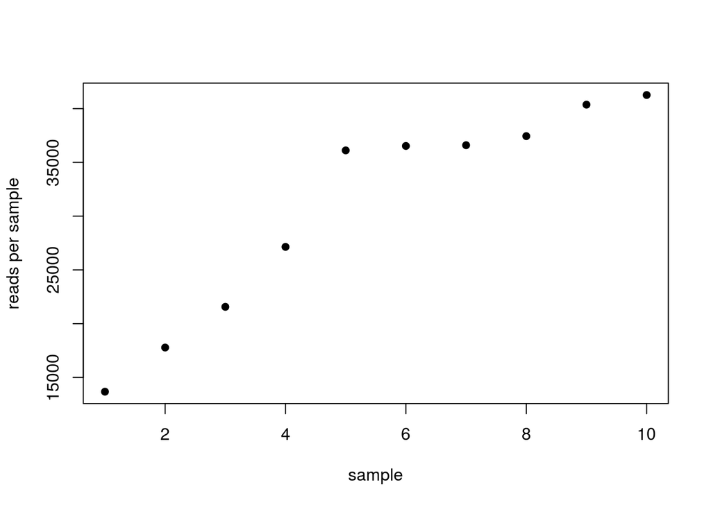

# 2) Normalization to 13674 reads per sample

Let’s normalize the original dataset by randomly subsampling 13674 reads in each station:

```r
library(vegan)
tb10_mitags_t<-t(tb10_mitags)
otu_tb10_mitags_t_ss13674<-rrarefy(tb10_mitags_t, 13674)
```

The normalized table shows the following dimensions and format:

```
## [1]    10 44069
```

```
##        OTU_1 OTU_2 OTU_3 OTU_4 OTU_5
## MP0311     0     0     0     1     1
## MP0528     2     0     0     8     0
## MP0778     0     0     0     0     0
## MP1176     0     0     0     0     1
## MP1421     0     0     0     0     0
```

Its content fits with the expected normalization values (13674 reads per station):

```r
rowSums(otu_tb10_mitags_t_ss13674)
```

```
## MP0311 MP0528 MP0778 MP1176 MP1421 MP1517 MP1672 MP1857 MP2243 MP2821
##  13674  13674  13674  13674  13674  13674  13674  13674  13674  13674
```

Let’s check out how many OTUs don’t appear in the new table:

```r
length(which(colSums(otu_tb10_mitags_t_ss13674)==0))
```

```
## [1] 37829
```

```r
otu_tb10_mitags_t_ss13674_no_cero<-otu_tb10_mitags_t_ss13674[,-(which(colSums(otu_tb10_mitags_t_ss13674)==0))]
dim(otu_tb10_mitags_t_ss13674_no_cero)
```

```
## [1]   10 6240
```

# 3) General community analysis

## 3.1) Richness and evenness (Shannon index)

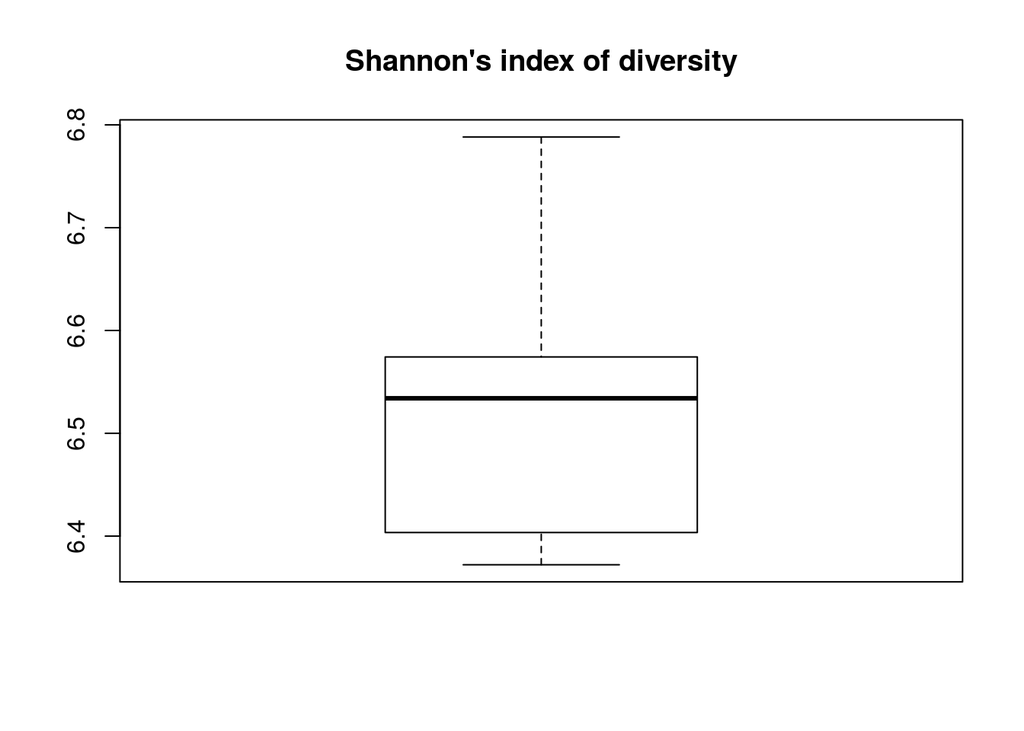

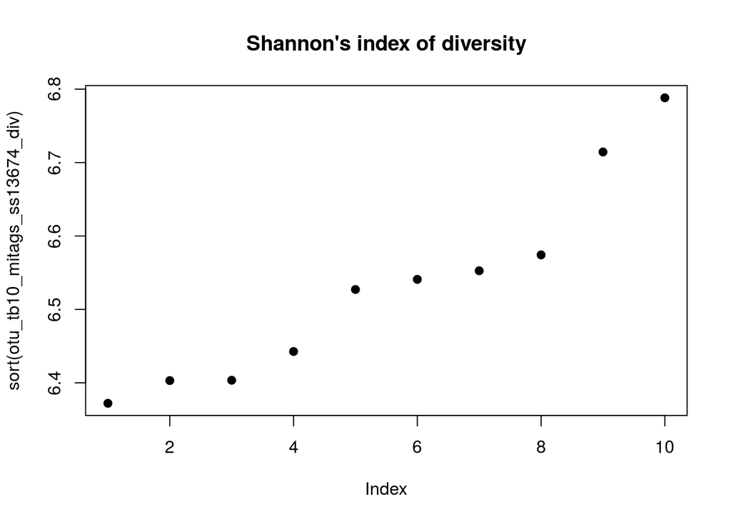

## 3.2) Richness: OTU number

Lowest number of OTUs per sample:

```
## [1] 1889
```

Maximum number of OTUs per sample:

```
## [1] 2431
```

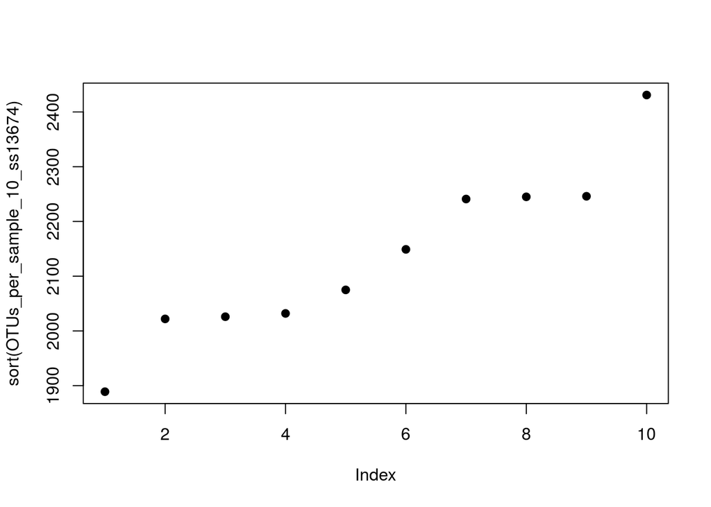

```r
plot(sort(OTUs_per_sample_10_ss13674), pch=19)
```

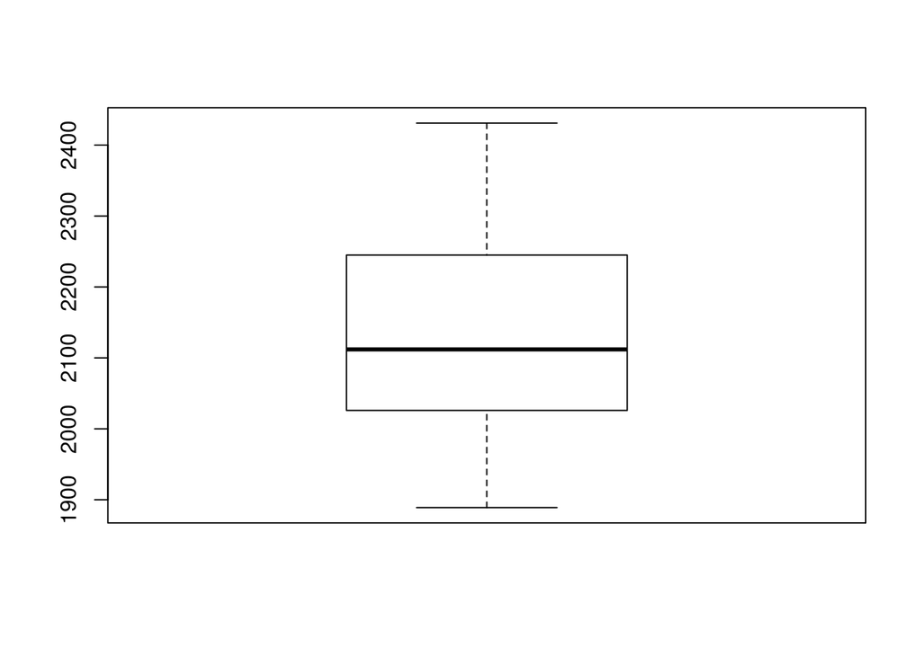

```r
boxplot(OTUs_per_sample_10_ss13674, pch=19)
```

## 3.3) Index of evenness

### 3.3.1) Pielou’s index

```r
pielou_evenness_10_ss13674 <- otu_tb10_mitags_ss13674_div/log(OTUs_per_sample_10_ss13674)
```

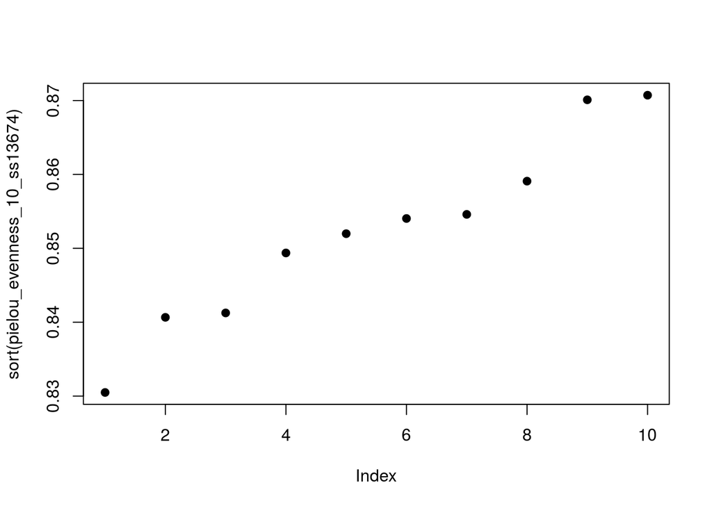

```r
plot(sort(pielou_evenness_10_ss13674), pch=19)
```

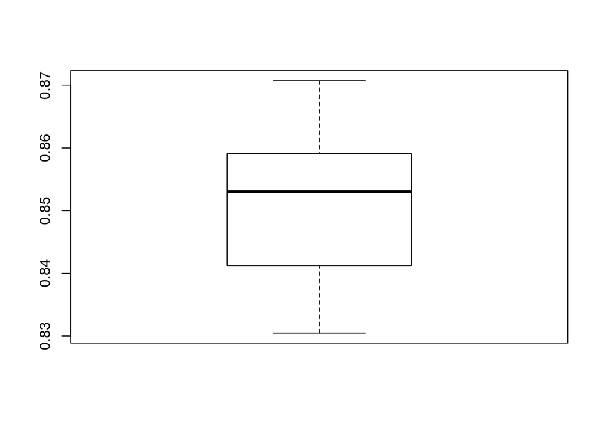

```r
boxplot(pielou_evenness_10_ss13674, pch=19)
```

```r
head(sort(colSums(otu_tb10_mitags_t_ss13674_no_cero), decreasing=T), n=10L)
```

```
## OTU_3009 OTU_2241 OTU_2660 OTU_5191  OTU_836  OTU_321 OTU_5093  OTU_145
##     3368     2330     1731     1577     1452     1419     1346     1178
## OTU_5172 OTU_1499
##     1126     1089
```

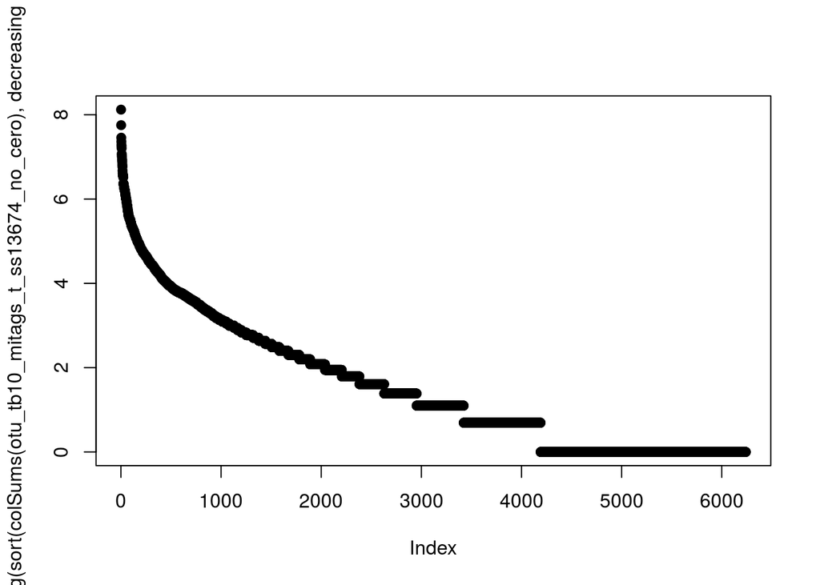

```r
plot(log(sort(colSums(otu_tb10_mitags_t_ss13674_no_cero), decreasing=T)), pch=19)
```

## 3.4) Abundance Models

### 3.4.1) Rank-Abundance or Dominance/Diversity Model (“radfit”)

The OTUs abundance distribution fits relativelly close to log-normal model.

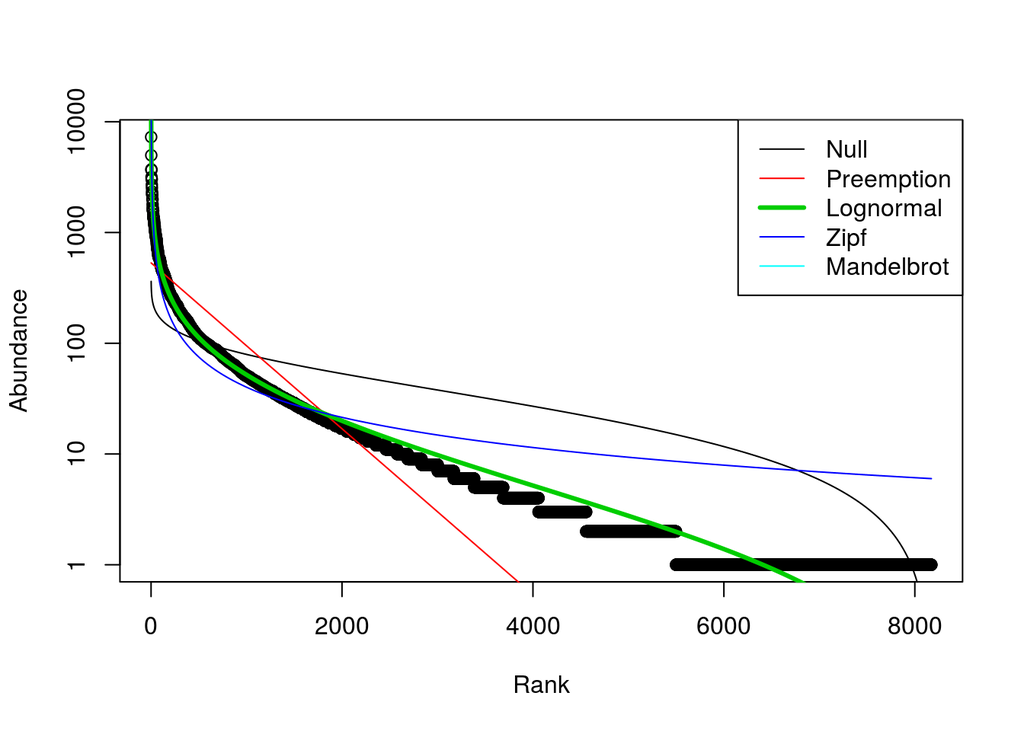

### 3.4.2) Preston’s Lognormal Model

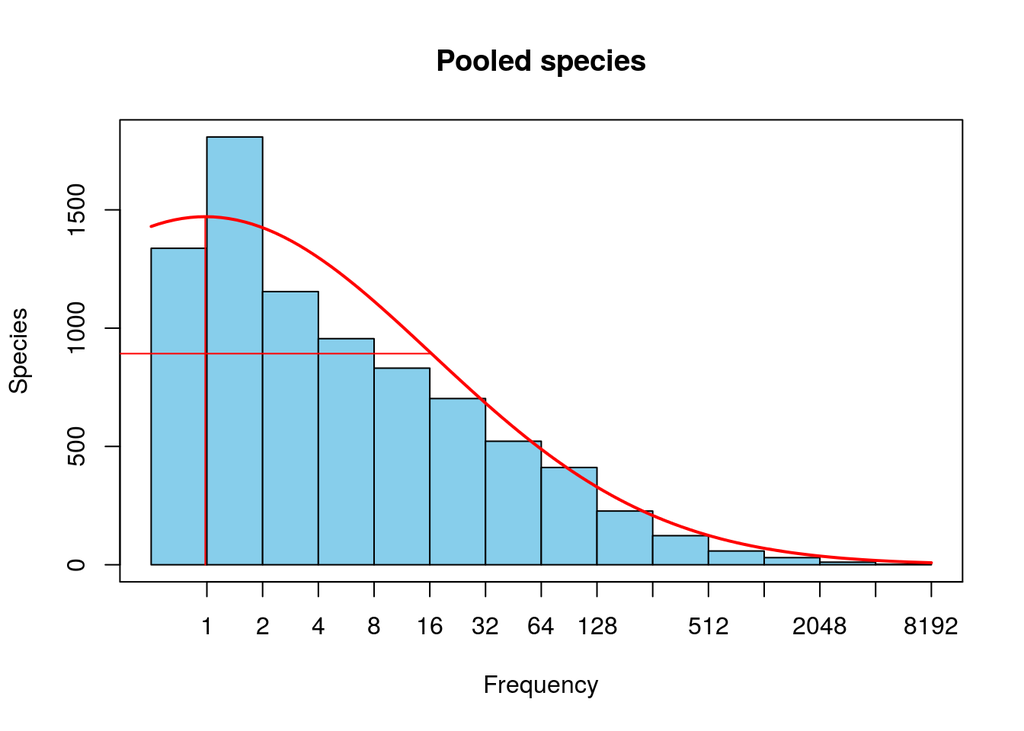

```r
otu_tb10_mitags_min13674_prestonfit<-prestonfit(colSums(tb10_mitags_t))
plot(otu_tb10_mitags_min13674_prestonfit, main="Pooled species")
```

```r
veiledspec(otu_tb10_mitags_min13674_prestonfit)
```

```
## Extrapolated     Observed       Veiled
##    14973.391     8173.000     6800.391
```

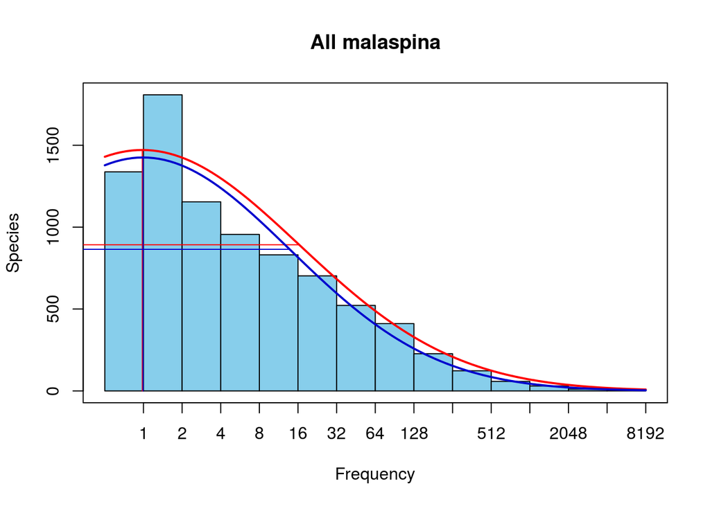

```
## Extrapolated     Observed       Veiled
##    13554.538     8173.000     5381.538
```

## 3.6) Beta diversity

### 3.6.1) Dissimilarity matrix using Bray-Curtis index:

The Bray-Curtis dissimilarity, constrained between 0 (minimum distance) and 1 (highest dissimilarity) allows us to quantify the differences between samples according to the composition and relative abundance of their OTUs. In our dataset, most of the samples pairs take dissimilarity values between 0.35 and 0.55, meaning that their composition is quiet similar.

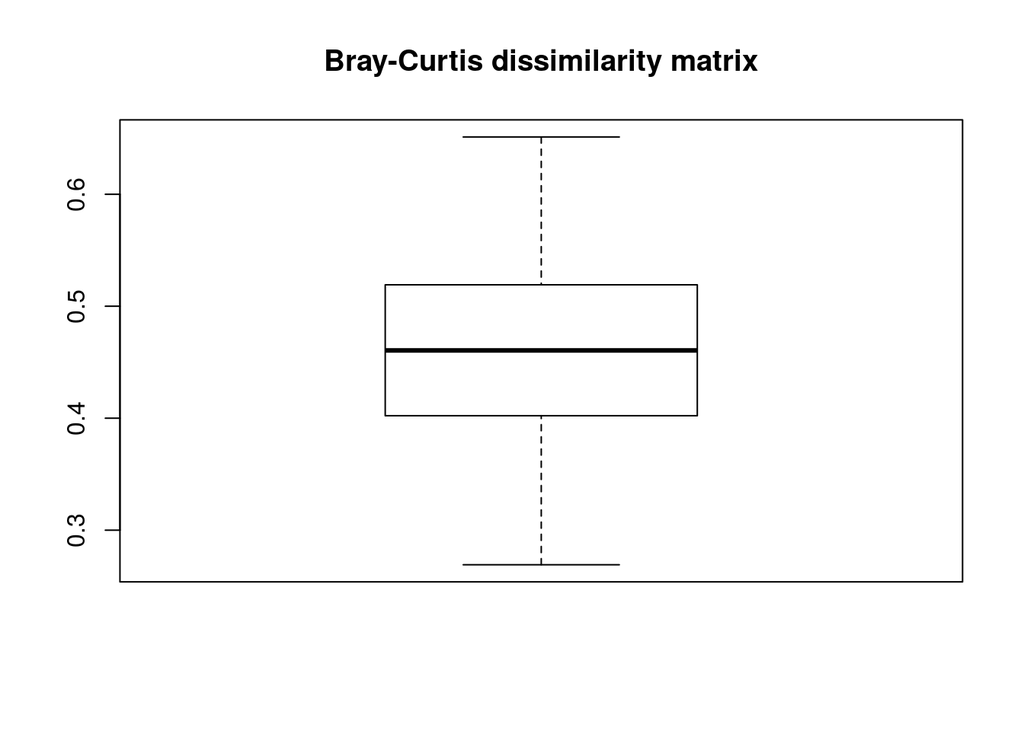

### 3.6.2) Hierarchical clustering

The only relatively evident clusters we can distinguish in the dendogram stand out in the very left side of the plot.

(To be done: assign Longhurst provinces information to each station and check if any of the central clusters is meaningful regarding to the samples’ geographical ubication)

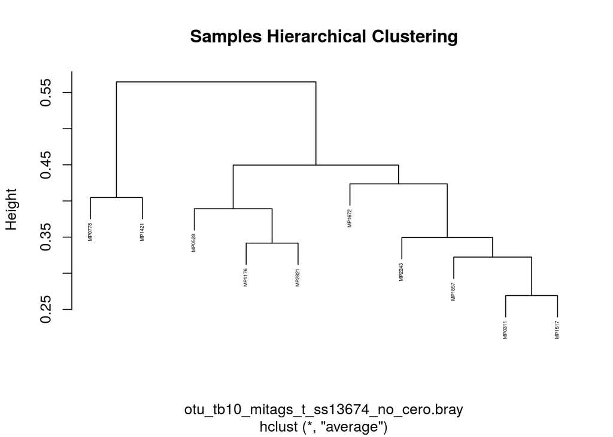

### 3.6.3) Non-metric multidimensional scaling

The stress parameter takes a value below 0.3, meaning that the plot is valid.

```
##
## Call:
## monoMDS(dist = otu_tb10_mitags_t_ss13674_no_cero.bray)
##
## Non-metric Multidimensional Scaling
##
## 10 points, dissimilarity 'bray', call 'vegdist(x = otu_tb10_mitags_t_ss13674_no_cero, method = "bray")'
##
## Dimensions: 2
## Stress:     0.08167352
## Stress type 1, weak ties
## Scores scaled to unit root mean square, rotated to principal components
## Stopped after 65 iterations: Stress nearly unchanged (ratio > sratmax)
```

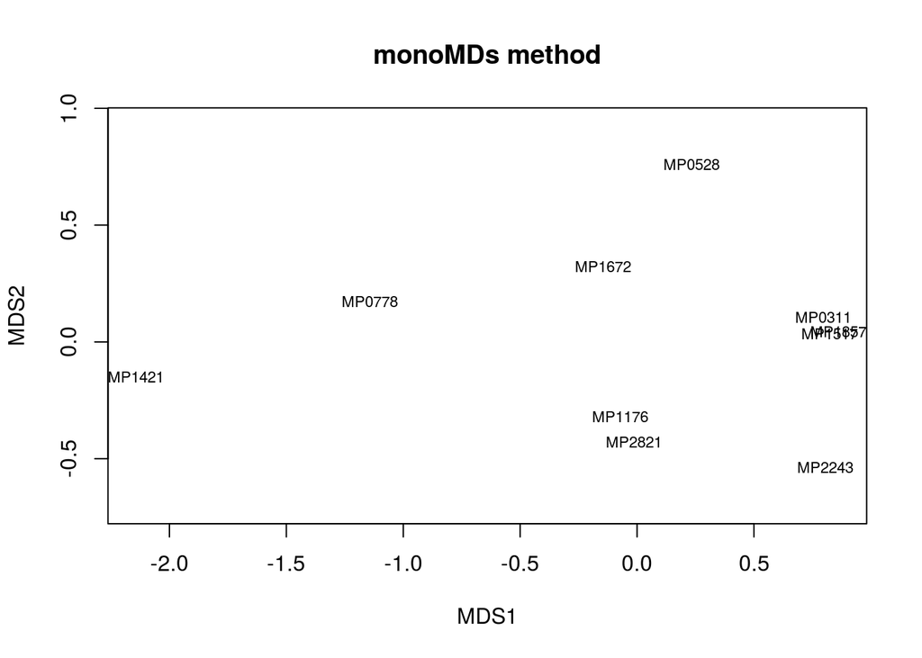

When implementing a most robut function for computing NMDS plots, the result is quiet the same:

```
## ... procrustes: rmse 0.001196274  max resid 0.00196941
## *** Solution reached
```

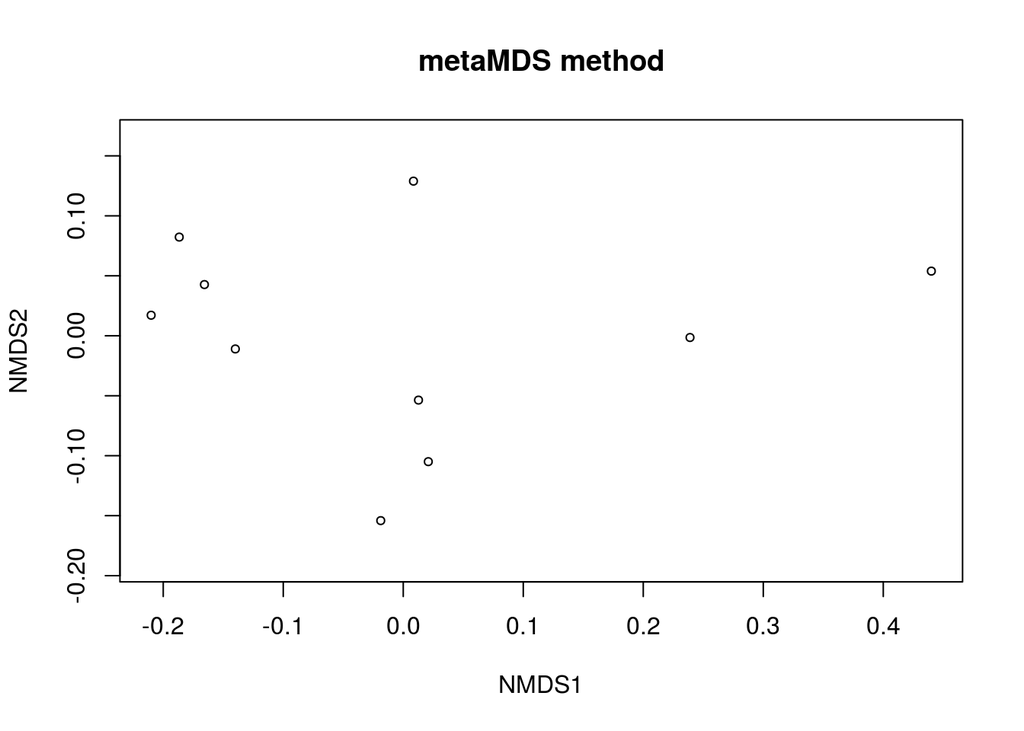

# 4) Geographical analysis

Working datasets:

1. Community matrix: otu_tb10_mitags_t_ss13674_no_cero

```r
dim(otu_tb10_mitags_t_ss13674_no_cero)
```

```
## [1]   10 6240
```

```r
otu_tb10_mitags_t_ss13674_no_cero[1:5, 1:5]
```

```
##        OTU_1 OTU_4 OTU_5 OTU_6 OTU_7
## MP0311     0     1     1     2     2
## MP0528     2     8     0     5     0
## MP0778     0     0     0     0     0
## MP1176     0     0     1     0     1
## MP1421     0     0     0     1     0
```

2. Community Bray-Curtis: otu_tb10_mitags_t_ss13674_no_cero.bray

```r
otu_tb10_mitags_t_ss13674_no_cero.bray<-as.matrix(otu_tb10_mitags_t_ss13674_no_cero.bray)
```

3. Stations distances in km: geo_distances_MP_10_ss13674

```r
dim(geo_distances_MP_10_ss13674)
```

```
## [1] 10 10
```

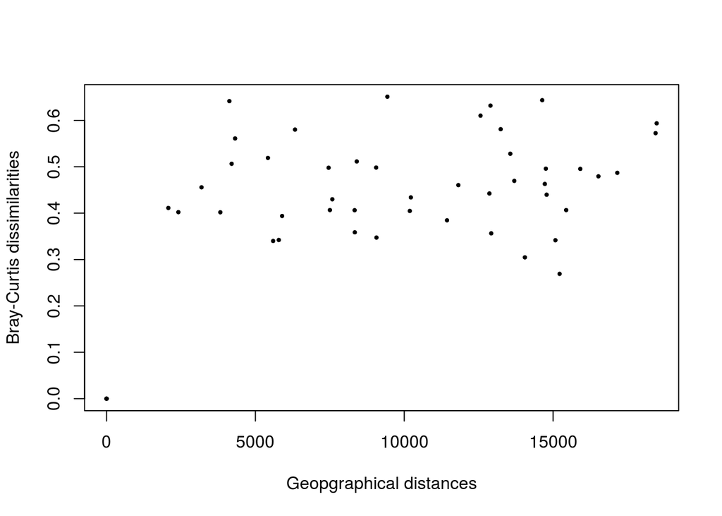

```r
plot(geo_distances_MP_10_ss13674, otu_tb10_mitags_t_ss13674_no_cero.bray, pch=19, cex=0.4, xlab="Geopgraphical distances", ylab="Bray-Curtis dissimilarities")
```

## 4.1) Mantel correlograms

When implementing the Mantel Test, we obtain a very low statistic, meaning that the correlation between samples dissimilarity and geographical distances is weak; besides, it is not significant, so we shouldn’t consider the test meaningful.

```r
mantel(geo_distances_MP_10_ss13674, otu_tb10_mitags_t_ss13674_no_cero.bray)
```

```
##
## Mantel statistic based on Pearson's product-moment correlation
##
## Call:
## mantel(xdis = geo_distances_MP_10_ss13674, ydis = otu_tb10_mitags_t_ss13674_no_cero.bray)
##
## Mantel statistic r: 0.1079
##       Significance: 0.166
##
## Upper quantiles of permutations (null model):
##   90%   95% 97.5%   99%
## 0.148 0.187 0.240 0.303
## Permutation: free
## Number of permutations: 999
```

Maximum distance between samples:

```
## [1] 18480.1
```

Minimum distance between samples:

```
## [1] 0
```

# 5) Abundance & occurence

In the following plot, we can appreciate the OTUs distribution according to their percentage of occurence and relative abundance. The red line keeps up OTUs that occur in more than 80% of the samples, the green line limits regionally rare OTUs (< 0.001%), and the blue one restricts regionally abundant OTUs (> 0.1%).

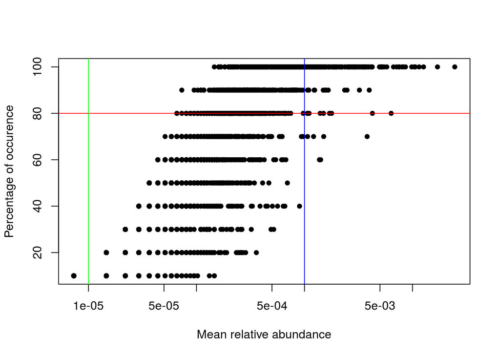

Regionally abundant OTUs (relative abundance over 0.1%):

```
##           mean_rabund perc_occur
## OTU_3009  0.024630686        100
## OTU_2241  0.017039637        100
## OTU_2660  0.012659061        100
## OTU_5191  0.011532836        100
## OTU_836   0.010618692        100
## OTU_321   0.010377358        100
## OTU_5093  0.009843499        100
## OTU_145   0.008614890        100
## OTU_5172  0.008234606        100
## OTU_1499  0.007964019        100
## OTU_2955  0.007517917        100
## OTU_330   0.007503291        100
## OTU_4948  0.007137633        100
## OTU_1519  0.006669592        100
## OTU_3067  0.006347813         80
## OTU_5223  0.005784701        100
## OTU_4584  0.005462922        100
## OTU_5701  0.005287407        100
## OTU_5148  0.005177710        100
## OTU_461   0.005141144        100
## OTU_5238  0.005141144        100
## OTU_856   0.005111891        100
## OTU_362   0.004943689        100
## OTU_5073  0.004256253         80
## OTU_402   0.004241626        100
## OTU_5130  0.004234313        100
## OTU_196   0.004190434        100
## OTU_3012  0.004190434        100
## OTU_1710  0.004088050        100
## OTU_5132  0.003978353         90
## OTU_5541  0.003912535        100
## OTU_5542  0.003890595        100
## OTU_4998  0.003802838         70
## OTU_3886  0.003758959        100
## OTU_8315  0.003678514        100
## OTU_5297  0.003663888        100
## OTU_703   0.003663888        100
## OTU_2738  0.003641948        100
## OTU_4935  0.003598069        100
```

[output cut: 130 more lines]

```
## OTU_5219  0.001067720         70
## OTU_5394  0.001060407         80
## OTU_8051  0.001053093        100
## OTU_8243  0.001053093        100
## OTU_3846  0.001053093        100
## OTU_299   0.001038467        100
## OTU_5207  0.001038467        100
## OTU_2349  0.001031154        100
## OTU_3946  0.001031154        100
## OTU_5606  0.001031154        100
## OTU_8294  0.001023841        100
## OTU_5066  0.001009215        100
## OTU_5109  0.001009215        100
## OTU_5282  0.001009215        100
## OTU_220   0.001001901        100
```

```r
dim(tb10_mitags_ss13674_abundant_sorted)
```

```
## [1] 184   2
```

Proportion of regionally abundant OTUs (%):

```
## [1] 2.939767
```

Cosmopolitan OTUs (abundance over 0.1% and occurence in more than 80% of samples):

```
##          mean_rabund perc_occur
## OTU_3009 0.024630686        100
## OTU_2241 0.017039637        100
## OTU_2660 0.012659061        100
## OTU_5191 0.011532836        100
## OTU_836  0.010618692        100
## OTU_321  0.010377358        100
## OTU_5093 0.009843499        100
## OTU_145  0.008614890        100
## OTU_5172 0.008234606        100
## OTU_1499 0.007964019        100
## OTU_2955 0.007517917        100
## OTU_330  0.007503291        100
## OTU_4948 0.007137633        100
## OTU_1519 0.006669592        100
## OTU_5223 0.005784701        100
## OTU_4584 0.005462922        100
## OTU_5701 0.005287407        100
## OTU_5148 0.005177710        100
## OTU_461  0.005141144        100
## OTU_5238 0.005141144        100
## OTU_856  0.005111891        100
## OTU_362  0.004943689        100
## OTU_402  0.004241626        100
## OTU_5130 0.004234313        100
## OTU_196  0.004190434        100
## OTU_3012 0.004190434        100
## OTU_1710 0.004088050        100
## OTU_5541 0.003912535        100
## OTU_5542 0.003890595        100
## OTU_3886 0.003758959        100
## OTU_8315 0.003678514        100
## OTU_5297 0.003663888        100
## OTU_703  0.003663888        100
## OTU_2738 0.003641948        100
## OTU_4935 0.003598069        100
## OTU_3617 0.003576130        100
## OTU_1839 0.003517625        100
## OTU_5513 0.003429867        100
## OTU_476  0.003349422        100
```

[output cut: 114 more lines]

```
## OTU_220  0.001001901        100
## OTU_5132 0.003978353         90
## OTU_1214 0.003225099         90
## OTU_5472 0.002479158         90
## OTU_1558 0.002354834         90
## OTU_1430 0.001660085         90
## OTU_578  0.001586953         90
## OTU_5232 0.001579640         90
## OTU_7758 0.001550388         90
## OTU_3115 0.001491882         90
## OTU_2449 0.001243235         90
## OTU_5270 0.001228609         90
## OTU_5107 0.001096972         90
## OTU_5373 0.001089659         90
## OTU_5366 0.001067720         90
```

```r
dim(otu_tb10_mitags_ss13674_cosmop_sorted)
```

```
## [1] 168   2
```

Proportion of cosmopolitan OTUs (%):

```
## [1] 2.684135
```

Number and proportion (%) of rare OTUs:

```r
dim(otu_tb10_mitags_ss13674_rabund_percoccur[otu_tb10_mitags_ss13674_rabund_percoccur$mean_rabund < 0.00001 & otu_tb10_mitags_ss13674_rabund_percoccur$mean_rabund >0,])
```

```
## [1] 2050    2
```

```
## [1] 32.75284
```